# Etude de la biométrie humaine

Laura Braeckevelt, Laura Toubeau, Margaux Renier, Lisa Mussoi

14/11/2018

# 1 Introduction

Nous avons interrogé une série de personnes, selon des critères bien définis, sur leurs caractéristiques physiques (taille, masse, mensurations), leurs habitudes alimentaires ainsi que sur leur activité physique aussi bien de nature sportive que dans la cadre professionnel. Ces données une fois répertoriées, nous nous sommes lancés dans une analyse de la biométrie humaine.

[figure not shown]

*L’homme de Vitruve*

> GE: l’insertion d’une image est une bonne chose

# 2 But

Récolte de données autour de la biométrie humaine afin de tirer des conclusions, suite à une analyse statistique appronfondie, quant aux taux d’obésité dans le hainaut spécifiquement et les facteurs qui y sont liés.

> GE: le but est très vague et ne donne pas vraiment la question de recherche que vous allez vous poser sur ces données.

# 3 Matériels et méthodes

Nous avons interrogé plusieurs personnes dans une tranche d’âge de 15 à 70 ans. Ensuite, nous les avons pesé en considérant une seule et unique balance afin de conserver la même erreur pour toutes les valeurs. C’est d’ailleurs pour cette raison qu’une conversion en fonction de l’erreur calculée pour la balance de laboratoire fût nécessaire. Un mètre ruban nous a également servi à mesurer leur tour de poignet, leur tour de taille, leur tour de hanche et leur hauteur. De plus, plusieurs questions leur ont été posées concernant : leur âge, leur genre, leur activité physique, leur profession (sédentaire, intermédiaire, active), leur consommation d’alcool(nombre de verre par semaine), le nombre de fast-food par mois, de repas et de grignotage(s) par jour, la comsommation de viande hebdomadaire (quantitative) et leur lieu de résidence (dans le Hainaut ou non).

> GE: tout le paragraphe suivant n’est pas nécessaire

Dans un premier temps, ces diverses données ont été collectées et retranscrites dans une google sheet, cette googlesheet doit ensuite être importée. Pour ce faire, on utilise la fonction “read” et on colle le lien de la google sheet en le mettant en format “csv”. Ile est nécessaire que ces ces données soient filtrées pour supprimer les “NA” c’est-à-dire les données non encodées pour avoir des résulats plus clairs. Ils sont clairs certes mais doivent être également exploitables sous forme de graphiques, voilà pourquoi, pour bien commencer à travailler, on définit les variables numériques et les variables facteurs. En dernier lieu, on effectue quelques tests et graphiques afin de pouvoir analyser et représenter les résultats de cette expérience.

```r
#import data

#biometry_2018 <- read$csv("https://docs.google.com/spreadsheets/d/e/2PACX-1vQoVtSWbENWzxbALxD0qyNDqxV4uSYqzLCtJgcNGE7ciT6nkWOjA9b6dMBHaSUY8Nw5f-mSpUEeN-3S/pub?output=csv ")

biometry_2018 <- readr::read_csv("https://docs.google.com/spreadsheets/d/e/2PACX-1vQoVtSWbENWzxbALxD0qyNDqxV4uSYqzLCtJgcNGE7ciT6nkWOjA9b6dMBHaSUY8Nw5f-mSpUEeN-3S/pub?output=csv", locale = locale(decimal_mark = ","))
write(biometry_2018, file = "../biometry_2018.rds", type = "rds")
```

> GE: la fonction summary() est intéressant pour prendre connaissance des données mais pas dans un rapport

```r
summary(biometry_2018)
```

```
##       id                taille          masse          masse_corr
##  Length:598         Min.   :1.470   Min.   : 37.50   Min.   : 37.70
##  Class :character   1st Qu.:1.649   1st Qu.: 59.00   1st Qu.: 59.15
##  Mode  :character   Median :1.710   Median : 69.00   Median : 69.80
##                     Mean   :1.709   Mean   : 71.65   Mean   : 72.16
##                     3rd Qu.:1.780   3rd Qu.: 80.30   3rd Qu.: 81.00
##                     Max.   :1.970   Max.   :171.60   Max.   :176.60
##                     NA's   :332     NA's   :332      NA's   :339
##       age          genre            tour_taille      tour_hanche
##  Min.   :10.0   Length:598         Min.   : 50.00   Min.   : 56.00
##  1st Qu.:20.0   Class :character   1st Qu.: 74.00   1st Qu.: 89.00
##  Median :26.0   Mode  :character   Median : 83.00   Median : 96.00
##  Mean   :33.8                      Mean   : 86.41   Mean   : 98.21
##  3rd Qu.:48.0                      3rd Qu.: 97.50   3rd Qu.:106.50
##  Max.   :85.0                      Max.   :170.00   Max.   :170.00
##  NA's   :333                       NA's   :345      NA's   :343
##   tour_poignet   acti_physique    acti_profession        alcool
##  Min.   :11.30   Min.   : 0.000   Length:598         Min.   : 0.000
##  1st Qu.:15.00   1st Qu.: 0.000   Class :character   1st Qu.: 0.000
##  Median :16.50   Median : 2.000   Mode  :character   Median : 2.000
##  Mean   :16.54   Mean   : 3.016                      Mean   : 3.882
##  3rd Qu.:18.00   3rd Qu.: 4.000                      3rd Qu.: 5.000
##  Max.   :21.00   Max.   :35.000                      Max.   :42.000
##  NA's   :344     NA's   :333                         NA's   :343
##     fastfood         repas       grignotage    proteine_animale
##  Min.   :0.000   Min.   :1.0   Min.   :0.000   Min.   : 0.000
##  1st Qu.:0.000   1st Qu.:2.0   1st Qu.:1.000   1st Qu.: 4.000
##  Median :0.500   Median :3.0   Median :2.000   Median : 7.000
##  Mean   :0.649   Mean   :2.7   Mean   :2.185   Mean   : 6.747
##  3rd Qu.:1.000   3rd Qu.:3.0   3rd Qu.:3.000   3rd Qu.: 9.000
##  Max.   :4.000   Max.   :5.0   Max.   :7.000   Max.   :17.000
##  NA's   :333     NA's   :333   NA's   :360     NA's   :383
##    hainaut          commentaire
##  Length:598         Length:598
##  Class :character   Class :character
##  Mode  :character   Mode  :character
##
##
##
##
```

```r
filter(biometry_2018,genre != "NA", hainaut!= "n") -> biometry
```

```r
biometry$acti_physique <- as.numeric(biometry$acti_physique)
```

```r
biometry$acti_physique <- as.numeric(biometry$acti_physique)
```

```r
biometry$alcool <- as.numeric(biometry$alcool)
```

```r
biometry$fastfood <- as.numeric(biometry$fastfood)
```

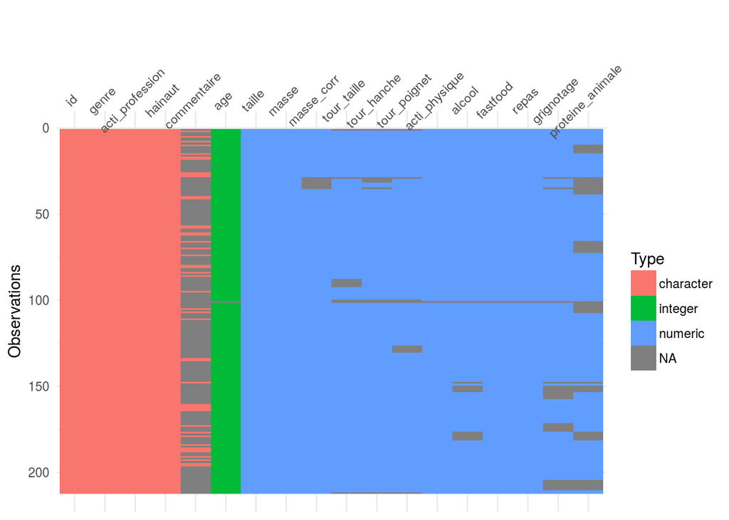

```r
visdat::vis_dat(biometry)
```

> GE: la fonction vis_dat() est intéressant pour prendre connaissance des données mais pas dans un rapport GE: L’importation, le rencodage et la sauvegarde des données provenant du net ne doit pas se trouver dans un rapport mais dans un script R de préférence.

# 4 Résultats

## 4.1 Graphiques

```r
Genre <- as.table(c(
  "Homme"   = 103,
  "Femme"    = 109))
```

### 4.1.1 Répartition des individus suivant le genre

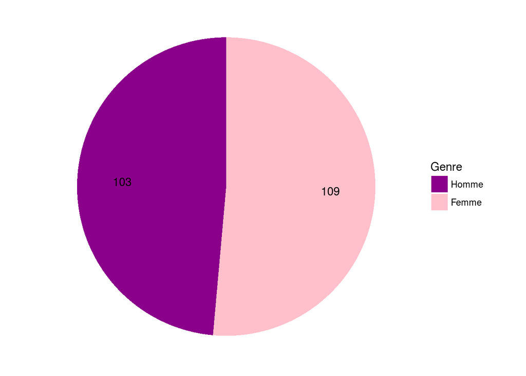

```r
chart(data = as_dataframe(Genre), n ~ 1 %fill=% factor(Var1, levels = Var1)) +
  geom_bar(width = 1, stat = "identity") +
  geom_text(f_aes(cumsum(rev(n)) - rev(n)/2  ~ 1.2, label = rev(n))) +
  labs(fill = "Genre") +
  coord_polar(theta = "y") +
  theme_void()+
  scale_fill_manual(values = c("darkmagenta", "pink"))
```

Il y a une répartition égale des hommes et des femmes, le nombre de femmes étant légèrement supérieur.

### 4.1.2 Masse des hommes et des femmes en fonction de leur âge

```r
filter(biometry,age > 15 ) -> biometry
```

```r
biometry <- mutate (biometry,
  age_schedule = case_when (
    age < 20 ~ "Adolescents",
    age >= 20 & age < 40 ~ "Jeunes adultes",
    age >= 40 & age < 60 ~ "Adultes",
    age >= 60 ~ "Aînés"
))
```

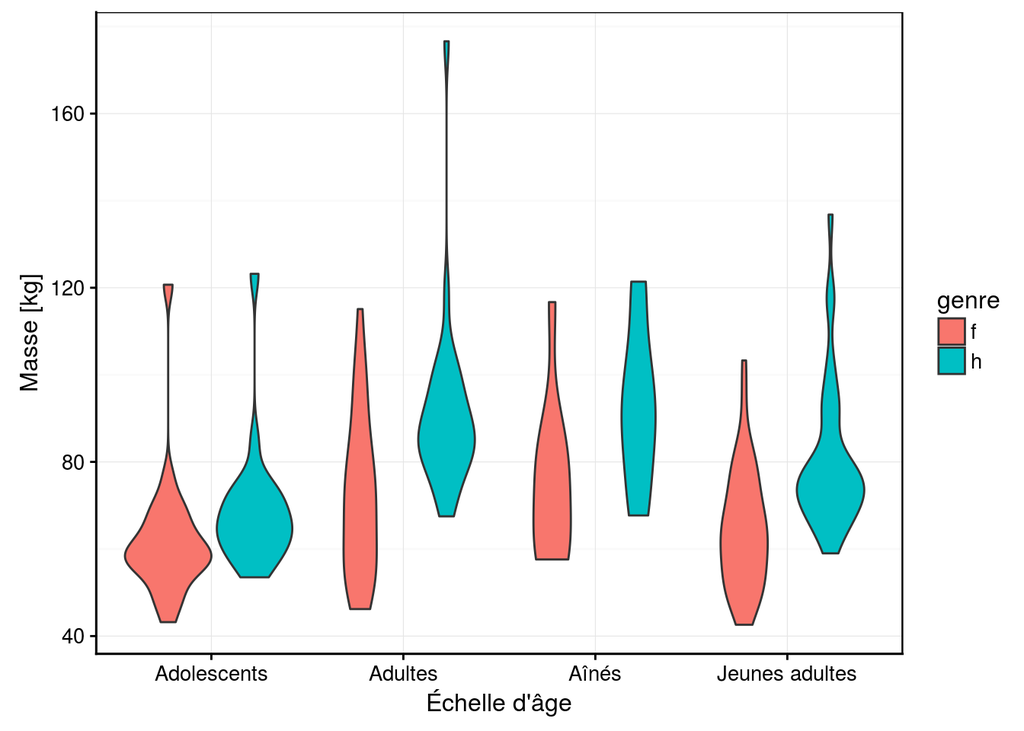

```r
chart(data = biometry, masse_corr ~ age_schedule %fill=% genre) +
  geom_violin()+
  labs(x = "Échelle d'âge", y = "Masse [kg]")
```

Nous avons regroupé les individus par tranches d’âge allant de 15 à 74 ans. Nous observons que les hommes ont tendance de manière générale à avoir une masse plus élevée que celle des femmes. Nous remarquons pour les femmes que la masse s’accroît avec l’âge pour la majorité, ceci est observable par le fait qu’à partir de 60ans la masse est strictement supérieure à 57kg ce qui n’est pas le cas pour les autres tranches d’âge. Chez les hommes, il en est de même lorsque l’on se concentre sur la majorité des individus même si des valeurs extrêmes ont été enregistrées à l’âge adulte avec des masses pouvant aller jusque 177kg. L’âge peut donc influencer la masse des individus.

### 4.1.3 Distribution de la masse des individus des différentes tranches d’âges sur base du nombre de fastfood par semaine.

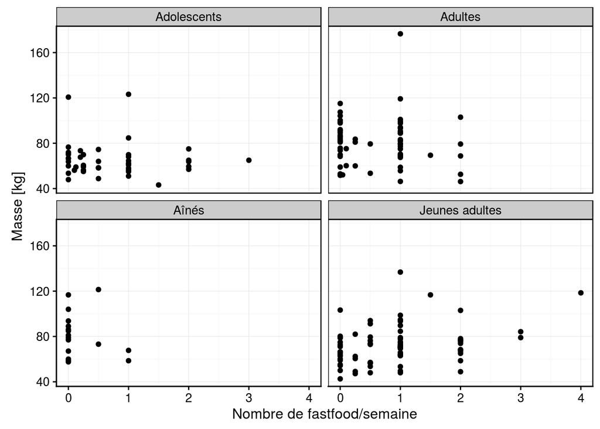

```r
chart(data = biometry, masse_corr ~ fastfood | age_schedule) +
  geom_point(na.rm = TRUE) +
  labs(x = "Nombre de fastfood/semaine", y = "Masse [kg]")
```

#### 4.1.3.1 IMC

```r
biometry <- mutate(biometry, imc= masse_corr / taille^2)
biometry
```

```
## # A tibble: 207 x 20
##    id    taille masse masse_corr   age genre tour_taille tour_hanche
##    <chr>  <dbl> <dbl>      <dbl> <int> <chr>       <dbl>       <dbl>
##  1 0_1     1.90  90.0       91.2    25 h             NA          NA
##  2 1_1     1.63  54.0       55.1    18 f             66.         91.
##  3 1_2     1.75  55.0       56.2    16 h             69.         88.
##  4 1_3     1.74  68.0       69.4    44 h             82.         90.
##  5 1_4     1.65  51.0       52.1    49 f             69.         93.
##  6 1_5     1.64  47.0       48.0    20 f             66.         87.
##  7 1_6     1.66  55.0       56.2    19 f             68.         92.
##  8 1_7     1.72  58.0       59.3    19 f             74.         88.
##  9 2_1     1.65  54.0       55.1    27 f             65.         88.
## 10 6_1     1.67  74.7       75.7    51 f            107.        110.
## # ... with 197 more rows, and 12 more variables: tour_poignet <dbl>,
## #   acti_physique <dbl>, acti_profession <chr>, alcool <dbl>,
## #   fastfood <dbl>, repas <dbl>, grignotage <dbl>, proteine_animale <dbl>,
## #   hainaut <chr>, commentaire <chr>, age_schedule <chr>, imc <dbl>
```

```r
biometry <- mutate(biometry,
  imc_schedule = case_when(
    imc < 18.5 ~ "sous_poids",
    imc >= 18.5 & imc < 25 ~ "poids_normal",
    imc >= 25 & imc < 30 ~ "surpoids",
    imc >= 30 ~ "obésité"
))

biometry
```

```
## # A tibble: 207 x 21
##    id    taille masse masse_corr   age genre tour_taille tour_hanche
##    <chr>  <dbl> <dbl>      <dbl> <int> <chr>       <dbl>       <dbl>
##  1 0_1     1.90  90.0       91.2    25 h             NA          NA
##  2 1_1     1.63  54.0       55.1    18 f             66.         91.
##  3 1_2     1.75  55.0       56.2    16 h             69.         88.
##  4 1_3     1.74  68.0       69.4    44 h             82.         90.
##  5 1_4     1.65  51.0       52.1    49 f             69.         93.
##  6 1_5     1.64  47.0       48.0    20 f             66.         87.
##  7 1_6     1.66  55.0       56.2    19 f             68.         92.
##  8 1_7     1.72  58.0       59.3    19 f             74.         88.
##  9 2_1     1.65  54.0       55.1    27 f             65.         88.
## 10 6_1     1.67  74.7       75.7    51 f            107.        110.
## # ... with 197 more rows, and 13 more variables: tour_poignet <dbl>,
## #   acti_physique <dbl>, acti_profession <chr>, alcool <dbl>,
## #   fastfood <dbl>, repas <dbl>, grignotage <dbl>, proteine_animale <dbl>,
## #   hainaut <chr>, commentaire <chr>, age_schedule <chr>, imc <dbl>,
## #   imc_schedule <chr>
```

```r
biometry$imc_schedule <- as.factor(biometry$imc_schedule)
```

```r
filter(biometry,imc_schedule != "NA") -> biometry
```

### 4.1.4 Répartition des individus suivant leur position sur l’échelle d’IMC

```r
biometry%>.%
  group_by(., imc_schedule)%>.%
  summarise(., n()) -> imc_schedule_count
```

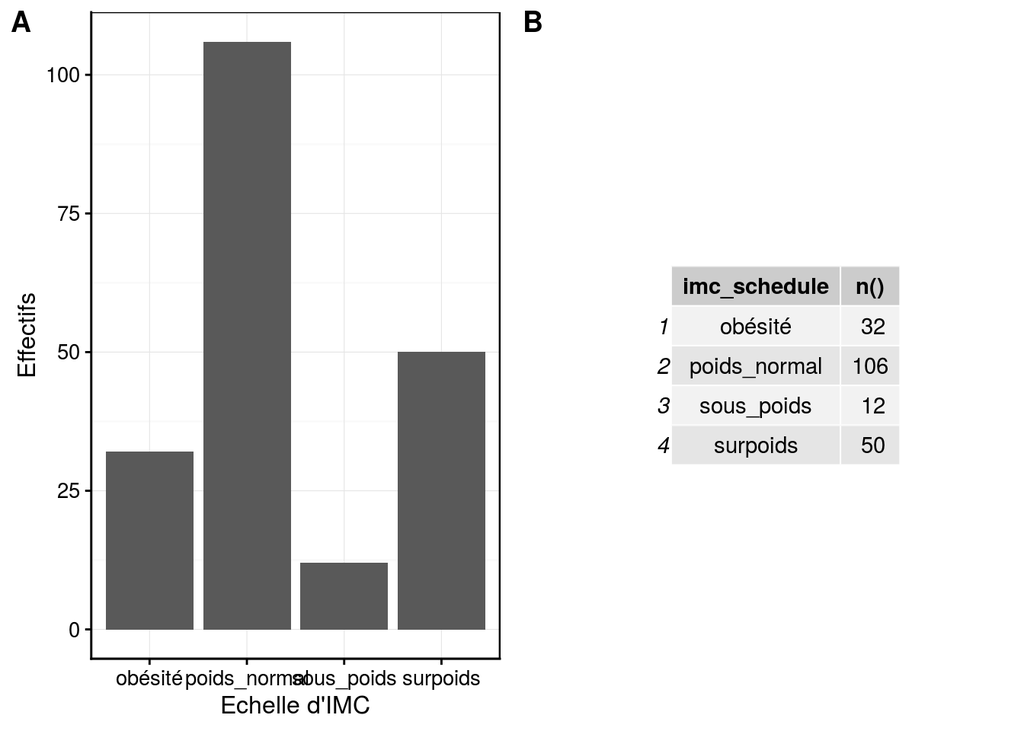

```r
a <- chart(data = biometry, ~ imc_schedule) +
  geom_bar(position = "dodge") +
  ylab("Effectifs") +
  scale_fill_viridis_d()+
  xlab("Echelle d'IMC")

b <- ggpubr::ggtexttable(head(imc_schedule_count))

combine_charts(list(a, b))
```

### 4.1.5 Répartiton au sein de chacun des paliers d’IMC du degré d’activité dans le cadre de la profession

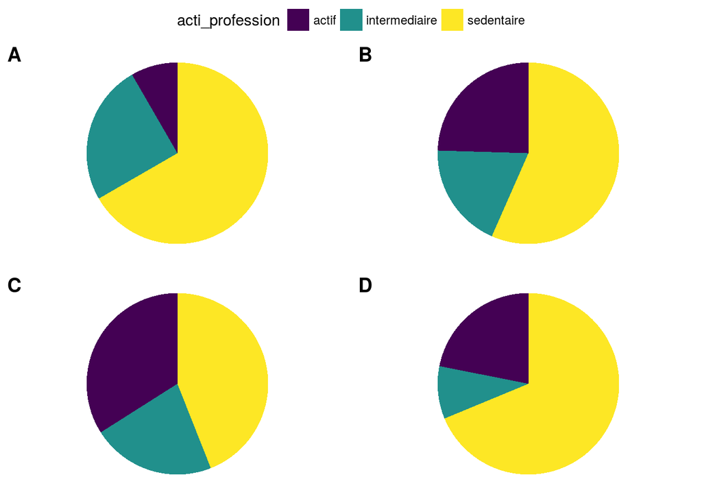

```r
 c <- filter (biometry, imc_schedule == "sous_poids")%>.%
  chart(., ~ imc_schedule %fill=% acti_profession) +
  geom_bar(width = 1) +
  coord_polar("y", start = 0) +
  theme_void() +
  scale_fill_viridis_d()

 d <- filter (biometry, imc_schedule == "poids_normal")%>.%
  chart(., ~ imc_schedule %fill=% acti_profession) +
  geom_bar(width = 1) +
  coord_polar("y", start = 0) +
  theme_void() +
  scale_fill_viridis_d()

 e <- filter (biometry, imc_schedule == "surpoids")%>.%
  chart(., ~ imc_schedule %fill=% acti_profession) +
  geom_bar(width = 1) +
  coord_polar("y", start = 0) +
  theme_void() +
  scale_fill_viridis_d()

 f <- filter (biometry, imc_schedule == "obésité")%>.%
  chart(., ~ imc_schedule %fill=% acti_profession) +
  geom_bar(width = 1) +
  coord_polar("y", start = 0) +
  theme_void() +
  scale_fill_viridis_d()

 combine_charts(list(c, d, e, f), common.legend = TRUE)
```

Ce graphique permet une vue d’ensemble des données. On constate que la majorité des personnes interrogées sont sédentaires. Cette sédentarité n’est pas un facteur déterminant de surpoids ou d’obésité étant donné qu’il y a quasi autant de personnes sédentaires chez les personnes en sous-poids que chez les personnes dites obèses. On remarque que l’activité professionelle n’influence pas beaucoup l’IMC ce qui est étonnnant.

### 4.1.6 Distribution de l’activité physique au sein des différents paliers de l’échelle d’IMC

```r
l <- chart(data = biometry, acti_physique ~ imc_schedule %col=% imc_schedule) +
  geom_violin()+
  labs(x = "Echelle d'IMC", y = "Activité physique (heures/semaine)")+
stat_summary(geom="point", fun.y= "mean", color = "blue", size=2)+
   theme(axis.text.x = element_text(angle=45,vjust = 1,hjust = 1))

m <- chart(data = biometry, ~ acti_physique %fill=% genre) +
  geom_histogram(bins = 25) +
  ylab("Effectifs") +
  xlab("Activité physique (heures/semaine)")
  scale_fill_viridis_d()
```

[output not shown]

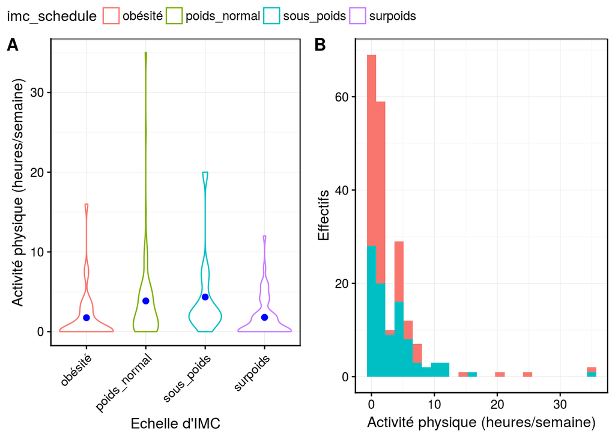

```r
 combine_charts(list(l, m), common.legend = TRUE)
```

On peut observer sur ce graphique que la grande majorité des personnes victimes de surpoids ou d’obésité ont tendance à ne pas effectuer d’activité physique, ceci pourrait donc être considéré comme un facteur d’obésité. De plus, les personnes ayant un poids normal et en sous-poids effectuent une activité physique dite plus régulière avec pour certains plus de 5 heures de sport par semaine. Un histogramme a été réalisé en parallèle afin de déterminer si il existait une différence entre le nombre d’heures de sport effectuées par les femmes et par les hommes. Visiblement ce n’est pas le cas, hommes et femmes effectuent un nombre d’heures de sport similaire (entre 0 et 10h), et pour chaque genre il existe des excpetions allant jusqu’à plus de 30h de sport par semaine, certaines personnes étant tout simplement plus sportives que d’autres.

### 4.1.7 Répartition des différents paliers sur l’échelle d’IMC suivant le tour de hanche, le tour de taille et le tour de poignet

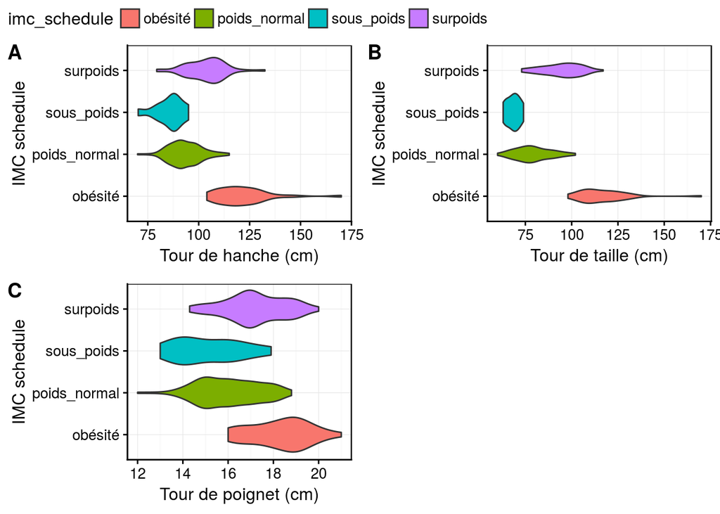

```r
a <- chart(data = biometry, tour_hanche ~ imc_schedule %fill=% imc_schedule) +
  geom_violin() +
  coord_flip()+
  xlab("IMC schedule")+
  ylab("Tour de hanche (cm)")

b <- chart(data = biometry, tour_taille ~ imc_schedule %fill=% imc_schedule) +
  geom_violin() +
  coord_flip()+
  xlab("IMC schedule")+
  ylab("Tour de taille (cm)")

c <- chart(data = biometry, tour_poignet ~ imc_schedule %fill=% imc_schedule) +
  geom_violin() +
  coord_flip()+
  xlab("IMC schedule")+
  ylab("Tour de poignet (cm)")

combine_charts(list(a, b, c ), common.legend = TRUE)
```

Sur base de ce graphique, nous pouvons relever que les valeurs pour les deux variables “tour de hanche”" et “tour de taille” se répartissent de manière plus ou moins semblables ce qui peut nous indiquer d’une part une certaine corrélation entre la répartiton générale de ces valeurs et la corpulence de l’individu ainsi qu’une certaine proportionalité dans les mensurations de la personne. Aussi, les individus considérés comme souffrants d’obésité sont ceux qui présentent les valeurs les plus élevées de tour de hanche et de taille (allant de +/- 100 à 170cm), suivis des cas de surpoids, de poids normal et enfin de sous-poids, ce qui n’est pas surprenant. La mesure de ces parties du corps est donc un méthode assez représentative de la corpulence générale de la personne, pouvant laisser apparaître un certain surpoids ou au contraire une maigreur significative. En ce qui concerne la mesure du tour de poignet, elle permet d’appuyer les résultats précédents en terme de surpoids et d’obésité. Néanmoins en ce qui concerne la maigreur il ne s’agit pas d’un bon indicateur étant donné que certaines personnes ayant un poids normal ont un tour de poignet encore inférieur aux personnes en situation de sous-poids même si une légère tendance peut être remarquée avec une tendance globale accrûe chez ces personnes entre 13 et 18 cm.

### 4.1.8 Distribution du nombre de grignotage par jour pour chacun des paliers de l’échelle d’IMC

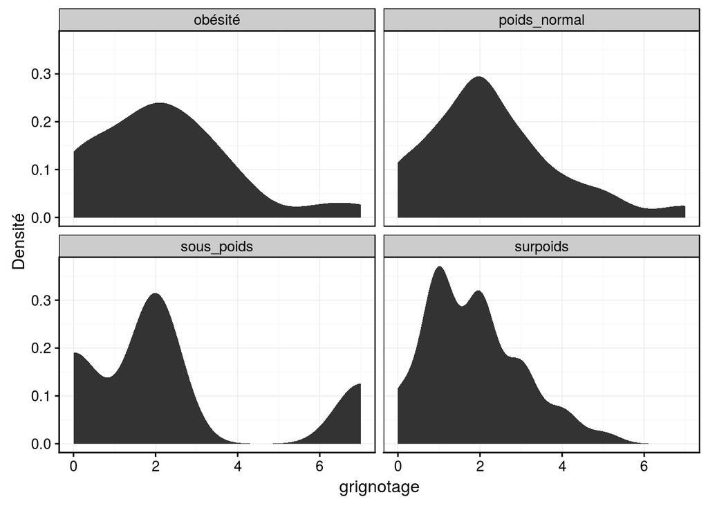

```r
chart(data = biometry, ~ grignotage | imc_schedule ) +
  stat_density(na.rm=TRUE) +
  ylab("Densité")
```

### 4.1.9 Distibution du nombre de repas par jour pour chacun des paliers sur l’échelle d’IMC

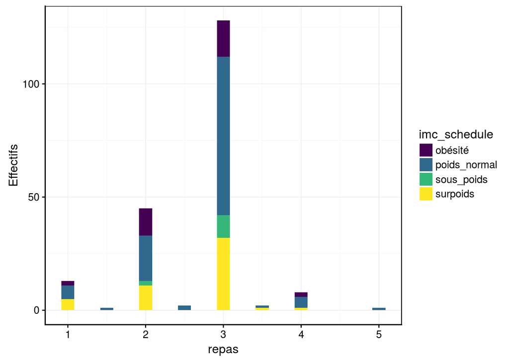

```r
chart(data = biometry, ~ repas %fill=% imc_schedule) +
  geom_histogram(bins = 25) +
  ylab("Effectifs") +
  scale_fill_viridis_d()
```

Une grande partie des personnes interrogées n’excèdent pas 3 repas par jour (la majorité étant à 3). Contrairement à ce qui pourrait être attendu, les personnes vicitmes de maigreurs n’effectuent pas moins de repas que les personnes de poids normal. Qui plus est, les personnes obèses ou en surpoids ne présentent pas non plus une tendance à effectuer plus de repas que les autres. Le nombre de repas par jour n’est donc pas un facteur influençant l’obésité.

### 4.1.10 Illustration de la consommation d’alcool des différents individus suivant leur activité professionnelle

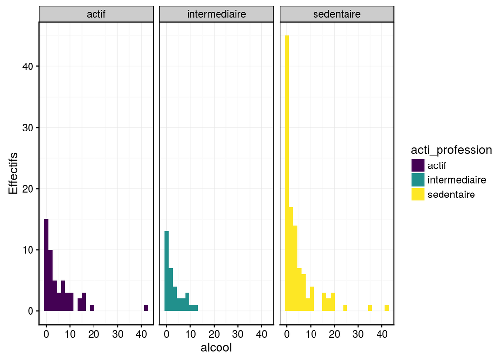

```r
chart(data = biometry, ~ alcool %fill=% acti_profession | acti_profession) +
  geom_histogram(bins = 25) +
  ylab("Effectifs") +
  scale_fill_viridis_d()
```

Nous constatons qu’il n’y a pas une différence drastique dans la consommation d’alcool des personnes actives, intermédiaires et sédentaires. Sur base de ce graphique nous pouvons uniquement remarquer que les personnes actives et sédentaires ont tendance à consommer davantage d’alcool que les personnes intermédiaires. Cependant, les personnes sédentaires une tendance à la consommation d’alcool un peu plus élevées avec des consommations pour une petite minorité pouvant aller jusqu’à 42 verres par semaine.

## 4.2 Test

### 4.2.1 Test de Student

```r
skim(biometry_2018)
```

```
## Skim summary statistics
##  n obs: 598
##  n variables: 18
##
## Variable type: character
##         variable missing complete   n min max empty n_unique
##  acti_profession     332      266 598   5  13     0        3
##      commentaire     547       51 598   6 129     0       45
##            genre     332      266 598   1   1     0        2
##          hainaut     332      266 598   1   1     0        2
##               id       0      598 598   3   5     0      598
##
## Variable type: integer
##  variable missing complete   n mean    sd p0 p25 p50 p75 p100     hist
##       age     333      265 598 33.8 16.73 10  20  26  48   85 ▇▇▃▂▅▂▁▁
##
## Variable type: numeric
##          variable missing complete   n  mean     sd    p0   p25   p50
##     acti_physique     333      265 598  3.02  4.49   0     0     2
##            alcool     343      255 598  3.88  6.25   0     0     2
##          fastfood     333      265 598  0.65  0.72   0     0     0.5
##        grignotage     360      238 598  2.18  1.6    0     1     2
##             masse     332      266 598 71.65 17.83  37.5  59    69
##        masse_corr     339      259 598 72.16 18.28  37.7  59.15 69.8
##  proteine_animale     383      215 598  6.75  3.7    0     4     7
##             repas     333      265 598  2.7   0.64   1     2     3
##            taille     332      266 598  1.71  0.098  1.47  1.65  1.71
##       tour_hanche     343      255 598 98.21 14.16  56    89    96
##      tour_poignet     344      254 598 16.54  1.62  11.3  15    16.5
##       tour_taille     345      253 598 86.41 17.24  50    74    83
##     p75   p100     hist
##    4     35    ▇▂▁▁▁▁▁▁
##    5     42    ▇▂▁▁▁▁▁▁
##    1      4    ▇▅▁▂▁▁▁▁
##    3      7    ▃▆▇▅▂▁▁▁
##   80.3  171.6  ▂▇▅▂▁▁▁▁
##   81    176.6  ▃▇▆▂▁▁▁▁
##    9     17    ▃▃▃▇▃▂▂▁
##    3      5    ▁▃▁▇▁▁▁▁
##    1.78   1.97 ▂▂▆▇▇▅▂▁
##  106.5  170    ▁▂▇▅▂▁▁▁
##   18     21    ▁▁▂▇▆▅▂▁
##   97.5  170    ▂▇▆▅▁▁▁▁
```

#### 4.2.1.1 Distribution du poids par genre pour la biométrie humaine

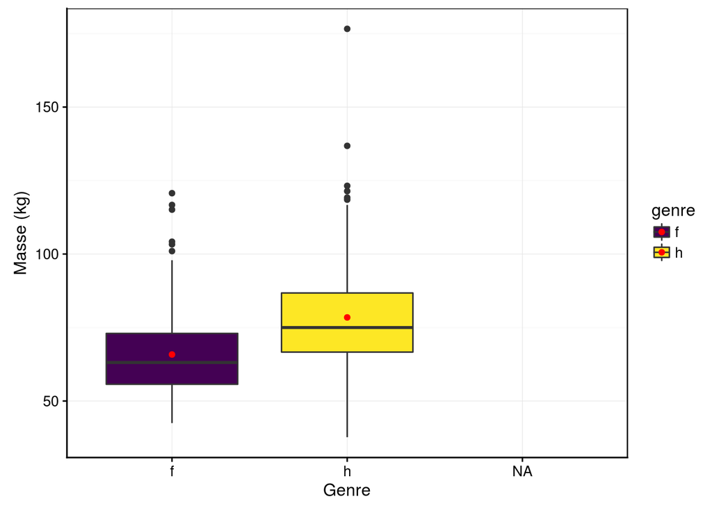

```r
chart(biometry_2018, masse_corr ~ genre %fill=% genre) + geom_boxplot(na.rm = TRUE)+
  scale_fill_viridis_d()+
  ylab("Masse (kg)")+
  xlab("Genre")+
  stat_summary(geom = "point", fun.y="mean", col="red")
```

On observe que les hommes tendent à avoir une masse plus importante que celle des femmes mais cette différence est-elle significative ou peut-elle être juste liée au hasard de l’échantillonnage ? Pour y répondre, nous devons élaborer un test d’hypothèse qui va confronter les hypothèses suivantes (en se basant sur les moyennes) :

H0 : les moyennes du poids des hommes et des femmes ne sont pas significatvements différentes  
H1 : les moyennes du poids des hommes et des femmes sont différentes

```r
t.test(data = biometry_2018, masse_corr ~ genre,
  alternative = "two.sided", conf.level = 0.95, var.equal = TRUE)
```

```
##
##  Two Sample t-test
##
## data:  masse_corr by genre
## t = -5.9078, df = 257, p-value = 1.095e-08
## alternative hypothesis: true difference in means is not equal to 0
## 95 percent confidence interval:
##  -16.821183  -8.410707
## sample estimates:
## mean in group f mean in group h
##        65.82713        78.44308
```

```r
biometry_women %>.%
  mutate(., group  = labelise(
    factor(paste(acti_profession, genre, sep = "-")),
    "Groupe activité professionnelle - genre", units = NA)) ->
  biometry_women
```

#### 4.2.1.2 Masse des femmes en fonction de leur activité professionnelle

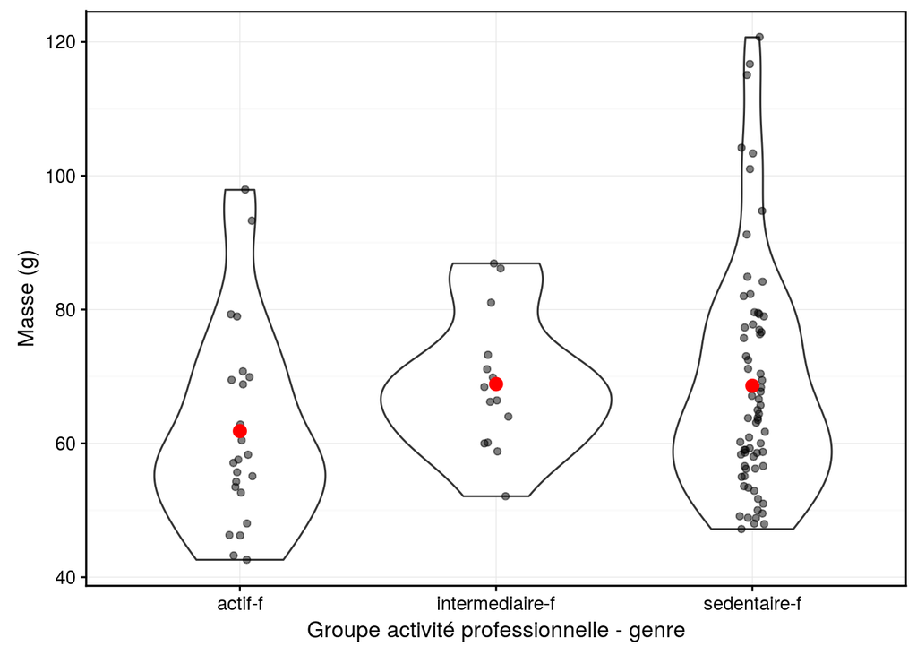

```r
chart(data = biometry_women, masse_corr ~ group) +
  geom_violin() +
  geom_jitter(width = 0.05, alpha = 0.5) +
  geom_point(data = group_by(biometry_women, group) %>.%
    summarise(., means = mean(masse_corr, na.rm = TRUE)),
    f_aes(means ~ group), size = 3, col = "red")+
  ylab("Masse (g)")
```

On distingue en rouge la moyenne et les observations individuelles en noir semi-transparent superposées à des graphiques en violon.

Pour que l’ANOVA puisse être appliquée deux conditions sont absolument nécessaires :  
1) Distribution normale des résidus  
2) Il doit y avoir homoscédaticité

La condition d’homoscédaticité peut être vérifiée à l’aide d’un test de Bartlett. Ses hypothèses sont :  
H0:Il y a homoscédaticité  
H1:Il y n’y a pas d’homoscédaticité, on parle alors d’hétéroscédaticité

Considérons un seuil α de 5% pour nos tests.

```r
bartlett.test(data = biometry_women, masse_corr ~ group)
```

```
##
##  Bartlett test of homogeneity of variances
##
## data:  masse_corr by group
## Bartlett's K-squared = 4.8574, df = 2, p-value = 0.08815
```

Nous ne rejettons pas H0 car il y a homoscédasticité. En effet p-value > 0.05 qui est notre seuil α.

Nous pouvons donc réaliser notre ANOVA :

```r
anova(anova. <- lm(data = biometry_women, masse_corr ~ group))
```

```
## Analysis of Variance Table
##
## Response: masse_corr
##            Df  Sum Sq Mean Sq F value Pr(>F)
## group       2   836.3  418.17  1.6206 0.2028
## Residuals 103 26577.9  258.04
```

```r
filter(biometry ,genre != "f") -> biometry_man
```

```r
biometry_man %>.%
  mutate(., group  = labelise(
    factor(paste(acti_profession, genre, sep = "-")),
    "Groupe activité professionnelle - genre", units = NA)) ->
  biometry_man
```

#### 4.2.1.3 Masse des hommes en fonction de leur activité professionnelle

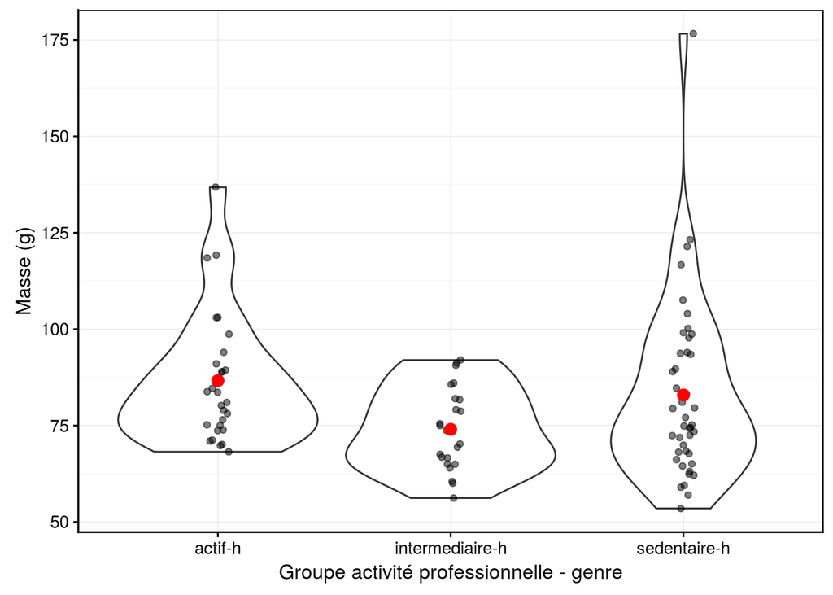

```r
chart(data = biometry_man, masse_corr ~ group) +
  geom_violin() +
  geom_jitter(width = 0.05, alpha = 0.5) +
  geom_point(data = group_by(biometry_man, group) %>.%
    summarise(., means = mean(masse_corr, na.rm = TRUE)),
    f_aes(means ~ group), size = 3, col = "red")+
  ylab("Masse (g)")
```

Considérons un seuil α de 5% pour nos tests.

```r
bartlett.test(data = biometry_man, masse_corr ~ group)
```

```
##
##  Bartlett test of homogeneity of variances
##
## data:  masse_corr by group
## Bartlett's K-squared = 14.15, df = 2, p-value = 0.0008462
```

Nous rejettons H0 car il n’y a pas homoscédasticité. En effet p-value << 0.05 qui est notre seuil α.

Essayons de stabiliser la variance avce le logarithme népérien de masse_corr.

```r
biometry_man %>.%
  mutate(., log_masse_corr = ln(masse_corr)) ->
  biometry_man
bartlett.test(data = biometry_man, log_masse_corr ~ group)
```

```
##
##  Bartlett test of homogeneity of variances
##
## data:  log_masse_corr by group
## Bartlett's K-squared = 8.0569, df = 2, p-value = 0.0178
```

La variance n’est pas stabilisée.

Une transformation à l’aide de puissance peut être réalisée:

```r
biometry_man %>.%
  mutate(., masse5 = masse_corr^5) ->
  biometry_man

bartlett.test(data = biometry_man, masse5 ~ group)
```

```
##
##  Bartlett test of homogeneity of variances
##
## data:  masse5 by group
## Bartlett's K-squared = 105.12, df = 2, p-value < 2.2e-16
```

Cette transformation ne stabilise pas la variance. Peu importe les modifications apportées à notres jeu de données, nous restons en-dessous du seuil α de 5%.

Sans cette condition d’homoscédaticité, le test de l’ANOVA n’est pas applicable et non adéquat. Il faut donc réaliser un test de Kruskal-Wallis.

### 4.2.2 Test de Kruskal-Wallis

Le test de Kuskal-Wallis utilise les hypothèses suivantes :  
H0 : Les rangs moyens sont significativement les mêmes.  
H1 : Il existe au moins deux rangs moyens différents.

```r
kruskal.test(data = biometry_man, masse_corr ~ group)
```

```
##
##  Kruskal-Wallis rank sum test
##
## data:  masse_corr by group
## Kruskal-Wallis chi-squared = 7.1629, df = 2, p-value = 0.02784
```

Nous rejettons ici H0 au seuil α de 5% ce qui signifie qu’il y a au minimum une différence entre les masses au seuil α de 5%.

Notre analyse n’est pas terminée. Nous devons maintenant réaliser un test post-hoc non paramétrique.

```r
summary(kw_comp. <- nparcomp::nparcomp(data = biometry_man, masse_corr ~ group))
```

```
##
##  #------Nonparametric Multiple Comparisons for relative contrast effects-----#
##
##  - Alternative Hypothesis:  True relative contrast effect p is less or equal than 1/2
##  - Type of Contrast : Tukey
##  - Confidence level: 95 %
##  - Method = Logit - Transformation
##  - Estimation Method: Pairwise rankings
##
##  #---------------------------Interpretation----------------------------------#
##  p(a,b) > 1/2 : b tends to be larger than a
##  #---------------------------------------------------------------------------#
##
##
##  #------------Nonparametric Multiple Comparisons for relative contrast effects----------#
##
##  - Alternative Hypothesis:  True relative contrast effect p is less or equal than 1/2
##  - Estimation Method: Global Pseudo ranks
##  - Type of Contrast : Tukey
##  - Confidence Level: 95 %
##  - Method = Logit - Transformation
##
##  - Estimation Method: Pairwise rankings
##
##  #---------------------------Interpretation--------------------------------------------#
##  p(a,b) > 1/2 : b tends to be larger than a
##  #-------------------------------------------------------------------------------------#
##
##  #----Data Info-------------------------------------------------------------------------#
##            Sample Size
## 1         actif-h   28
## 2 intermediaire-h   23
## 3    sedentaire-h   43
##
##  #----Contrast--------------------------------------------------------------------------#
##                                actif-h intermediaire-h sedentaire-h
## intermediaire-h - actif-h           -1               1            0
## sedentaire-h - actif-h              -1               0            1
## sedentaire-h - intermediaire-h       0              -1            1
##
##  #----Analysis--------------------------------------------------------------------------#
##                            Comparison Estimator Lower Upper Statistic
## 1      p( actif-h , intermediaire-h )     0.269 0.135 0.463 -2.747670
## 2         p( actif-h , sedentaire-h )     0.399 0.257 0.561 -1.467251
## 3 p( intermediaire-h , sedentaire-h )     0.602 0.432 0.750  1.408887
##      p.Value
## 1 0.01704213
## 2 0.31145415
## 3 0.34069142
##
##  #----Overall---------------------------------------------------------------------------#
##   Quantile    p.Value
## 1 2.342636 0.01704213
##
##  #--------------------------------------------------------------------------------------#
```

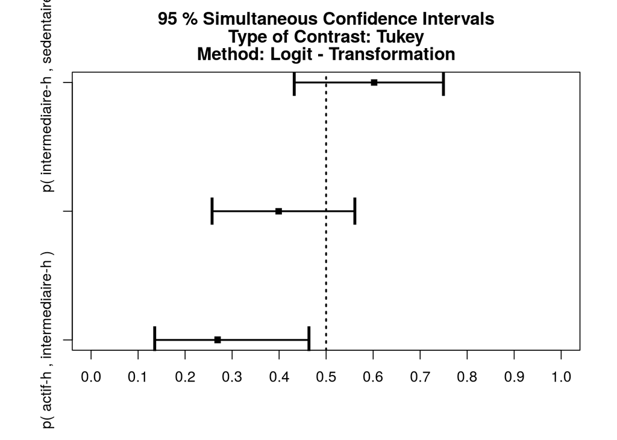

```r
plot(kw_comp.)
```